# Using epinow() for running in production mode

The *EpiNow2* package contains functionality to run `estimate_infections()` in production mode, i.e. with full logging and saving all relevant outputs and plots to dedicated folders in the hard drive. This is done with the `epinow()` function, that takes the same options as `estimate_infections()` with some additional options that determine, for example, where output gets stored and what output exactly. The function can be a useful option when, e.g., running the model daily with updated data on a high-performance computing server to feed into a dashboard. For more detail on the various model options available, see the Examples vignette, for more on the general modelling approach the Workflow, and for theoretical background the Model definitions vignette

# Running the model on a single region

To run the model in production mode for a single region, set the parameters up in the same way as for `estimate_infections()` (see the Workflow vignette). Here we use the example delay and generation time distributions that come with the package. This should be replaced with parameters relevant to the system that is being studied.

```r
library("EpiNow2")
options(mc.cores = 4)
reported_cases <- example_confirmed[1:60]
reporting_delay <- LogNormal(mean = 2, sd = 1, max = 10)
delay <- example_incubation_period + reporting_delay
rt_prior <- LogNormal(mean = 2, sd = 1)
```

We can then run the `epinow()` function with the same arguments as `estimate_infections()`.

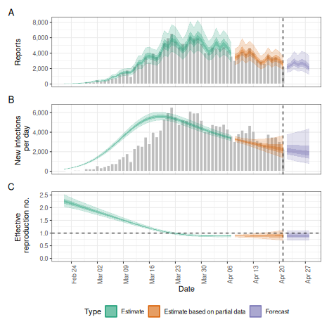

```r
res <- epinow(reported_cases,
  generation_time = gt_opts(example_generation_time),
  delays = delay_opts(delay),
  rt = rt_opts(prior = rt_prior),
  logs = NULL
)
plot(res)
```

By default, logging messages are printed to the console indicating the progress of the model fitting and where log files can be found. Here we have set `logs = NULL` to suppress these messages. If you want summarised results and plots to be written out where they can be accessed later you can use the `target_folder` argument.

# Running the model simultaneously on multiple regions

The package also contains functionality to conduct inference contemporaneously (if separately) in production mode on multiple time series, e.g. to run the model on multiple regions. This is done with the `regional_epinow()` function.

Say, for example, we construct a dataset containing two regions, `testland` and `realland` (in this simple example both containing the same case data).

```r
cases <- example_confirmed[1:60]
cases <- data.table::rbindlist(list(
  data.table::copy(cases)[, region := "testland"],
  cases[, region := "realland"]
 ))
```

To then run this on multiple regions using the default options above, we could use

```r
region_rt <- regional_epinow(
  data = cases,
  generation_time = gt_opts(example_generation_time),
  delays = delay_opts(delay),
  rt = rt_opts(prior = rt_prior),
  logs = NULL
)
## summary
region_rt$summary$summarised_results$table
```

```
#>      Region New infections per day Expected change in reports
#>      <char>                 <char>                     <fctr>
#> 1: realland    2249 (1388 -- 3630)          Likely decreasing
#> 2: testland    2250 (1378 -- 3720)          Likely decreasing
#>    Effective reproduction no.           Rate of growth
#>                        <char>                   <char>
#> 1:         0.89 (0.71 -- 1.1) -0.028 (-0.093 -- 0.036)
#> 2:         0.89 (0.71 -- 1.1) -0.029 (-0.095 -- 0.042)
#>    Doubling/halving time (days)
#>                          <char>
#> 1:             -24 (19 -- -7.5)
#> 2:             -24 (17 -- -7.3)
## plot
```

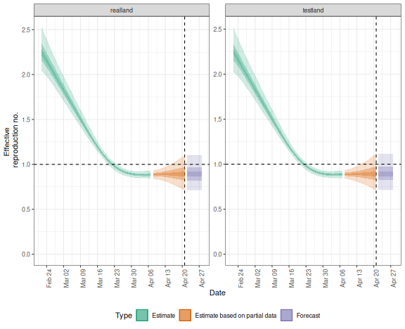

```r
region_rt$summary$plots$R
```

If instead, we wanted to use the Gaussian Process for `testland` and a weekly random walk for `realland` we could specify these separately using the `opts_list()` function from the package and `modifyList()` from `R`.

```r
gp <- opts_list(gp_opts(), cases)
gp <- modifyList(gp, list(realland = NULL), keep.null = TRUE)
rt <- opts_list(rt_opts(), cases, realland = rt_opts(rw = 7))
region_separate_rt <- regional_epinow(
  data = cases,
  generation_time = gt_opts(example_generation_time),
  delays = delay_opts(delay),
  rt = rt, gp = gp,
  logs = NULL
)
## summary
region_separate_rt$summary$summarised_results$table
```

```
#>      Region New infections per day Expected change in reports
#>      <char>                 <char>                     <fctr>
#> 1: realland    2037 (1024 -- 3864)          Likely decreasing
#> 2: testland      1975 (46 -- 3612)          Likely decreasing
#>    Effective reproduction no.           Rate of growth
#>                        <char>                   <char>
#> 1:         0.85 (0.62 -- 1.2)   -0.04 (-0.11 -- 0.038)
#> 2:         0.95 (0.74 -- 1.7) -0.011 (-0.086 -- 0.049)
#>    Doubling/halving time (days)
#>                          <char>
#> 1:             -17 (18 -- -6.2)
#> 2:               -60 (14 -- -8)
## plot
```

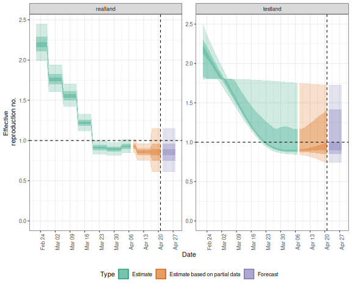

```r
region_separate_rt$summary$plots$R
```